# HW_12

Jillian Sarazen

4/25/2020

Advanced ggplotting

1. For this exerise, use your newly-developed ggplot chops to create some nice graphs from your own data (If you do not have a good data frame to use for graphics, use one of the many built-in data frames from R (other than mpg, which we are using in class)). Experiment with different themes, theme base sizes, aesthetics, mappings, and faceting. When you are finished, try exporting them to high quality pdfs, jpgs, eps files, or other formats that you would use for submission to a journal.

In this exercise, I encourage you to improve your graphics with elements that we have not (yet) covered in ggplot. For example, can you change the labels on a facet plot so that they are more informative than the variable names that are supplied from your data frame? Can you figure out how to add text annotations, lines and arrows to your graph? Can you figure out how to use custom colors that you have chosen for your fills and lines? Your resources for these explorations are google, Stack Overflow – and Lauren!

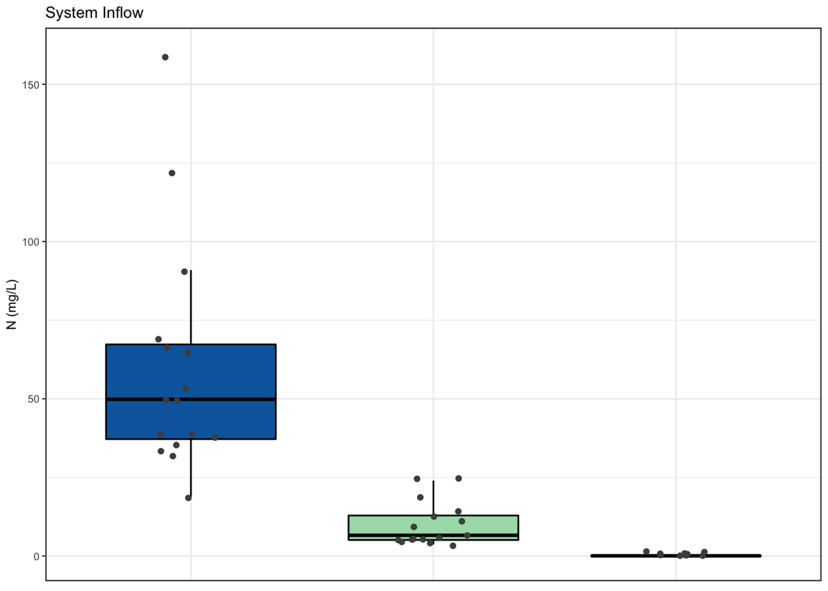

```r
# preliminaries
S_2019 <- read.csv("Silage_Hydrology_Table_2019_copy.csv", header = TRUE)
library(ggplot2)
library(cowplot)
library(ggthemes)
library(patchwork)
library(colorspace)
library(reshape2)

# set colors in a vector
my_cols <- c("#0868ac","#a8ddb5","#e0f3db")


######## Inflow N Concentrations ########
InflowTN <- S_2019$S1_TN_mg_L
InflowNH4 <- S_2019$S1_NH3_mg_N_L
InflowNO3 <- S_2019$S1_NO2_NO3_mg_N_L
Date <- S_2019$StartDate

# combine the data frames
df1 <- data.frame(Date, InflowTN, InflowNH4, InflowNO3)
df2 <- melt(df1, id.vars='Date')

# plot
n1 <- ggplot(df2, aes(x=variable, y=value, fill=variable)) +
        geom_boxplot(width=0.7, color="black",outlier.shape=NA) +
        labs(title="System Inflow",
             x=NULL,
             y="N (mg/L)") +
      geom_point(position=position_jitter(width=0.15, height=0.7),
             color="gray30",size=1.2)

n1.1 <- n1 + scale_fill_manual(values=my_cols) +
        theme_bw(base_size=8) +
        ylim(0,160) +
        theme(legend.position = "none",
              axis.text.x=element_blank(), axis.ticks.x=element_blank()) +
        panel_border(color = "gray0", size = 0.6)
print(n1.1)
```

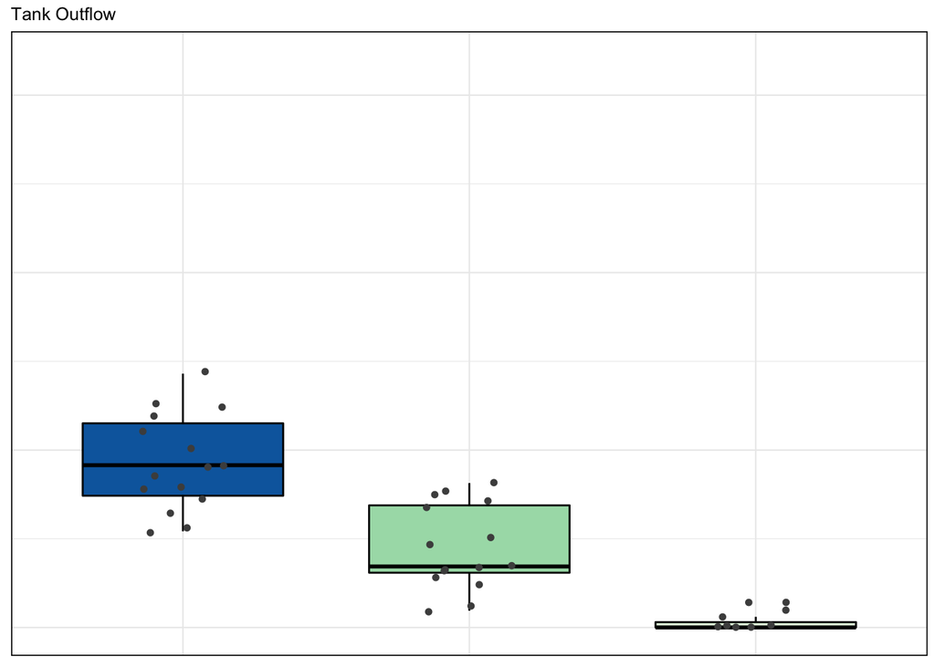

```r
####### TankOutflow N Concentrations ########
TankOutflowTN <- S_2019$S2_TN_mg_L
TankOutflowNH4 <- S_2019$S2_NH3_mg_N_L
TankOutflowNO3 <- S_2019$S2_NO2_NO3_mg_N_L
Date <- S_2019$StartDate

# combine the data frames
df1 <- data.frame(Date, TankOutflowTN, TankOutflowNH4, TankOutflowNO3)
df2 <- melt(df1, id.vars='Date')

# plot it up
n2 <- ggplot(df2, aes(x=variable, y=value, fill=variable)) +
        geom_boxplot(width=0.7, color="black",outlier.shape=NA) +
        labs(title="Tank Outflow",
             x=NULL,
             y=NULL) +
  geom_point(position=position_jitter(width=0.15,
                                      height=0.7),
             color="gray30",size=1.2)

n2.1 <- n2 + scale_fill_manual(values=my_cols) +
        theme_bw(base_size=8) +
        ylim(0,160) +
        theme(legend.position = "none",
              axis.text=element_blank(), axis.ticks=element_blank()) +
        panel_border(color = "gray0", size = 0.6)
print(n2.1)
```

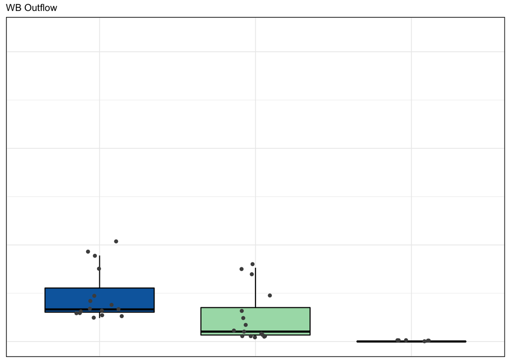

```r
###### WCB1 N Concentrations ########
WCB1_TN <- S_2019$S3_TN_mg_L
WCB1_NH4 <- S_2019$S3_NH3_mg_N_L
WCB1_NO3 <- S_2019$S3_NO2_NO3_mg_N_L
Date <- S_2019$StartDate

# combine the data frames
df1 <- data.frame(Date, WCB1_TN, WCB1_NH4, WCB1_NO3)
df2 <- melt(df1, id.vars='Date')

# plot it up
n3 <- ggplot(df2, aes(x=variable, y=value, fill=variable)) +
        geom_boxplot(width=0.7, color="black",outlier.shape=NA) +
        labs(title="WB Outflow",
             x=NULL,
             y=NULL) +
    geom_point(position=position_jitter(width=0.15, height=0.7),
             color="gray30",size=1.2)

n3.1 <- n3 + scale_fill_manual(values=my_cols) +
        theme_bw(base_size=8) +
        ylim(0,160) +
        theme(legend.position = "none", axis.text=element_blank(),
              axis.ticks=element_blank()) +
        panel_border(color = "gray0", size = 0.6)
print(n3.1)
```

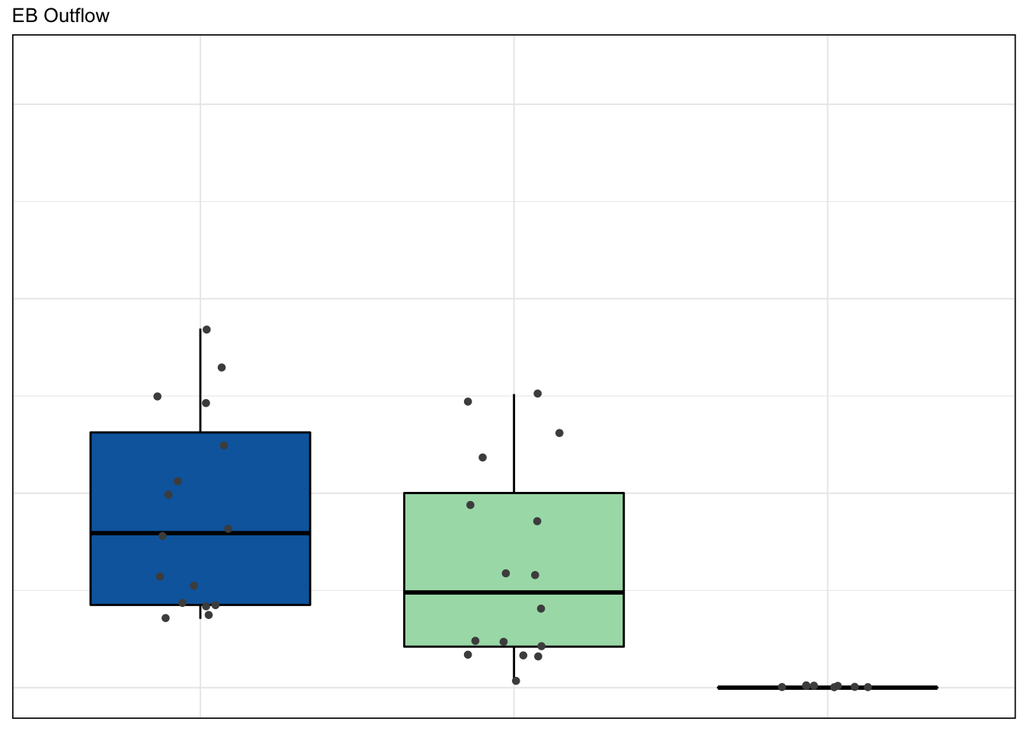

```r
###### WCB2 N Concentrations ########
WCB2_TN <- S_2019$S4_TN_mg_L
WCB2_NH4 <- S_2019$S4_NH3_mg_N_L
WCB2_NO3 <- S_2019$S4_NO2_NO3_mg_N_L
Date <- S_2019$StartDate

# combine the data frames
df1 <- data.frame(Date, WCB2_TN, WCB2_NH4, WCB2_NO3)
df2 <- melt(df1, id.vars='Date')

# plot it up
n4 <- ggplot(df2, aes(x=variable, y=value, fill=variable)) +
        geom_boxplot(width=0.7, color="black",outlier.shape=NA) +
        labs(title="EB Outflow",
             x=NULL,
             y=NULL) +
      geom_point(position=position_jitter(width=0.15,height=0.7),
             color="gray30",size=1.2)

n4.1 <- n4  + theme_bw(base_size=8) +
  scale_fill_manual(#labels = c("TN", "NH4+", "NOx-"),
    values=my_cols) +
        ylim(0,160) +
        #theme(legend.position = "bottom",
         #     legend.title =element_blank(),
          #    legend.text=element_text(size=10),
           #   legend.background=element_blank()) +
  theme(legend.position = "none") +
        theme(axis.text=element_blank(), axis.ticks.y=element_blank(),
        axis.ticks=element_blank()) +
        panel_border(color = "gray0", size = 0.6)

print(n4.1)
```

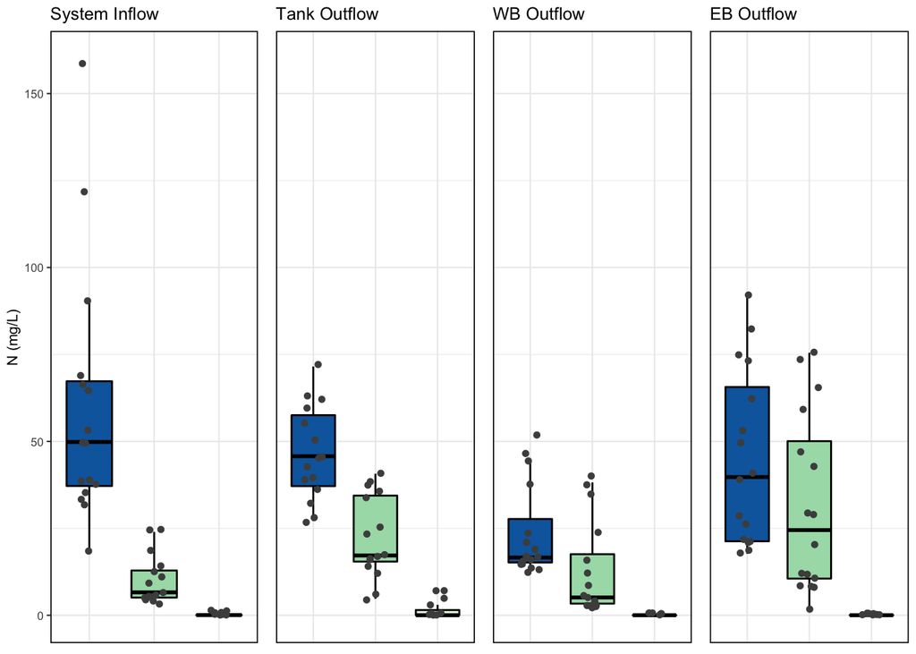

```r
# c(0.7,0.8) - to get the legend as part of the graph
# combine graphs into one

# originally I used cowplot Plot_grid function
z2 <- plot_grid(n1.1, n2.1, n3.1, n4.1,
               align = "h", ncol = 4, nrow = 1,
               rel_widths = c(1.1,.9,.9,.9))
print(z2)
```

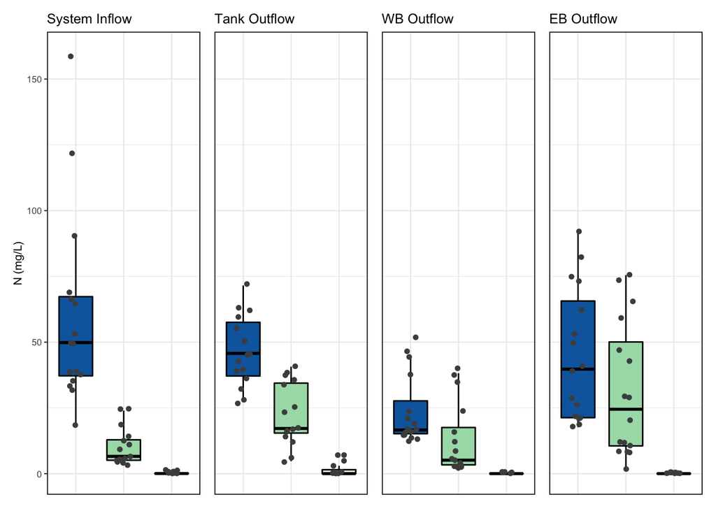

```r
# patchwork also works too
n1.1 + n2.1 + n3.1 + n4.1 + plot_layout(ncol=4)
```

```r
ggsave(plot = n4.1,
       filename="legend",
       width=5,
       height=6,
       units="in",
       device="jpeg")
ggsave(plot = z2,
          filename = "Silage_N_Concentrations_2019",
          width = 6.3,
          height = 2.5,
          units = "in",
          device = "jpeg")
```

Cool to use the points on the plots, and using the color vector to keep same colors throughout. Might change colors eventually… Need to figure out how to do the combined legend for the whole graph!